# Problem 4 (40 points)

Pump-probe spectroscopy can be applied to characterize the structure and dynamics of the excited states of molecules or nanomaterials. In a transient absorption experiment, a laser pulse is used to excite, or “pump”, the molecule or material into its excited state. The excited state then exhibits relaxation dynamics on the femtosecond or picosecond timescales. Before the system is permitted to relax fully back to its ground state, however, it is hit with a second laser pulse. This “probe” pulse is used to probe the population in the excited state at different temporal delays with respect to the initial excitation.

In a pump-probe spectroscopy experiment, you measure the decay in signal intensity ($I$ in arbitrary units) versus the time between the pump and probe pulses ($t$ or pump-probe delay in femtoseconds or fs). This time-resolved signal intensity is the convolution of the instrument reponse modeled by a Gaussian function with a full width half maximum of $\sigma$

$$ R(t) = A_{1} \exp \left( -\frac{t^{2}}{2\sigma^2} \right) $$

and the exponential decay of the excited states with a decay constant $\tau$

$$ S(t) = A_{2} \exp \left( -\frac{t}{\tau} \right) $$

yielding a model expression of

$$ I(t) = \int R(t-t')S(t')dt' = A \exp \left( \frac{\sigma^2}{2\tau^2} - \frac{t}{\tau} \right) \left( 1 - \text{erf} \left( \frac{\sigma^2-t\tau}{\sqrt{2}\sigma\tau} \right) \right) $$

Your system may also have a background signal with an intensity that drifts linearly with time (*i.e.*, $I_{background}(t)=I_0+I_1t$ ) such that your measured pump-probe signal can be modeled as:

$$ I_{measured}(t) = I_{background} + I = I_0 + I_1t + A \exp \left( \frac{\sigma^2}{2\tau^2} - \frac{t}{\tau} \right) \left( 1 - \text{erf} \left( \frac{\sigma^2-t\tau}{\sqrt{2}\sigma\tau} \right) \right) $$

Perform the following analyses given the measured dataset for the signal intensity $I_{measured}(t)$ in arbitrary units versus the pump-probe delay ($t$) in fs.

```python
import numpy as np
import matplotlib.pyplot as plt
import scipy

# Pump-probe delay or time in femtoseconds
t = np.arange(-200, 1020, 20)

# Measured intensity in arbitrary units
I_measured = np.array([0.58732184, 0.81579769, 0.604928, 0.73793651, 0.73260555, 0.87297814,
 0.91359141, 1.05232179, 1.21819683, 1.91310499, 2.50797839, 2.87510777,
 3.16053001, 3.06101081, 2.89121755, 2.74982955, 2.4542219, 2.20800238,
 2.11031955, 2.02921026, 1.80140641, 1.80595801, 1.61989405, 1.38412901,
 1.38083468, 1.33129836, 1.38238845, 1.24634688, 1.2670311,  1.26957547,
 1.13077104, 1.11290101, 1.226097,   1.21601642, 1.13941349, 1.06150816,
 1.18426828, 1.0548215,  0.96532705, 1.11886833, 1.11273344, 1.09509711,
 1.05375343, 1.20875434, 1.13676902, 1.12337623, 1.27984861, 1.1266991,
 1.18196528, 1.0586184,  1.23540257, 1.39180655, 1.19382239, 1.10404717,
 1.19425984, 1.13247449, 1.22813677, 1.21022106, 1.18393875, 1.39002982,
 1.27816627])
```

#### (a) Create a publication-quality scatter plot of $I_{measured}(t)$ versus pump-probe delay ($t$).

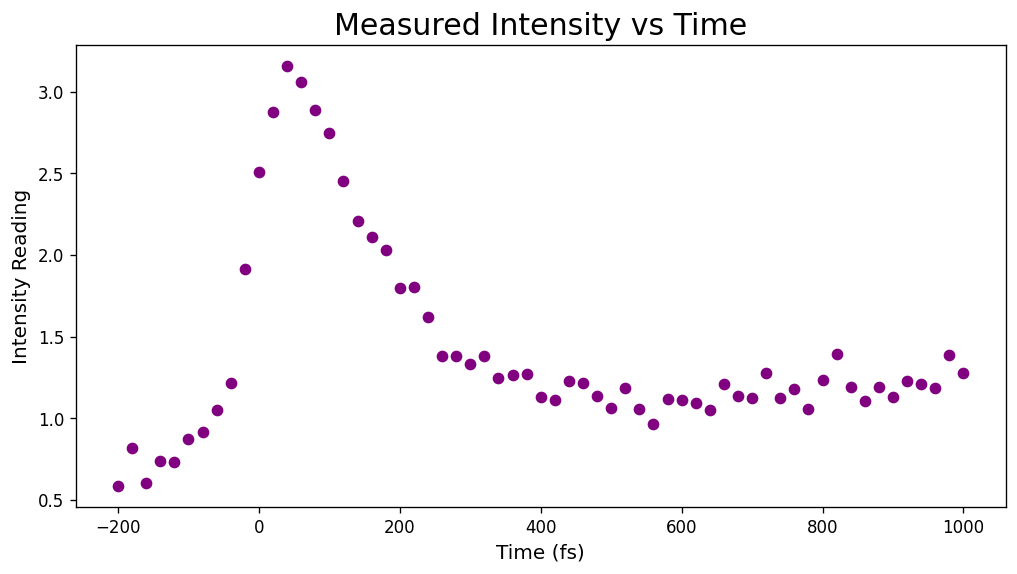

```python
plt.figure(figsize=(10, 5), dpi=120)
plt.subplot(111)
for i in range(len(t)):
        plt.plot(t[i], I_measured[i], color="purple", marker = 'o',linestyle = 'none')
plt.title('Measured Intensity vs Time', fontsize = 18)
plt.xlabel('Time (fs)', fontsize = 12)
plt.ylabel('Intensity Reading', fontsize = 12)
#plt.legend(loc = 'best')
plt.show()
```

#### (b) Perform a linear regression to determine the background signal ($I_{background}$) and generate a plot illustrating your linear background equation on the measured data.

You may need to adjust your dataset (e.g., trim it, filter it, etc.) to ensure that your linear regression is only performed where appropriate. Functions such as `concatenate` may be useful for this task on NumPy arrays, although please note that you may choose to take different approaches to accomplish the same goal. For more information about the `concatenate` function, see the documentation at https://numpy.org/doc/stable/reference/generated/numpy.concatenate.html#numpy-concatenate.

```
[3.68887945 4.09434456 4.38202663 4.60517019 4.78749174 4.94164242
 5.07517382 5.19295685 5.29831737 5.39362755 5.48063892 5.56068163
 5.6347896  5.70378247 5.768321   5.82894562]
[1.15073974 1.11874519 1.06167771 1.01153893 0.89780977 0.79208821
 0.74683938 0.70764668 0.5885677  0.5910912  0.48236075 0.32507107
 0.32268816 0.28615468 0.32381276 0.22021678]
[np.float64(-0.006734336977941164), np.float64(3.3180613920588207)]
```

[figure not shown]

```python
from scipy import stats
from scipy.optimize import curve_fit

def linear_regression(xs, ys):
    n = len(xs)
    sum_x = 0
    sum_y = 0
    sum_xy = 0
    sum_xx = 0
    for i in range(0,len(xs)):
        sum_x = sum_x + xs[i]
        sum_y = sum_y + ys[i]
        sum_xx = sum_xx + xs[i]**2
        sum_xy = sum_xy + ys[i]*xs[i]
    a_one = (n*sum_xy - sum_x*sum_y)/(n*sum_xx - sum_x**2)
    a_o = (sum_y/n) - a_one*(sum_x/n)
    return [a_one, a_o]

new_t = t[12:28]
print(np.log(new_t))
new_I = I_measured[12:28]
print(np.log(new_I))

linear_array = linear_regression(new_t,new_I)
print(linear_array)

curve = []
for i in range(len(new_t)):
    curve.append(new_t[i]*linear_array[0] +linear_array[1])

plt.figure(figsize=(10, 5), dpi=120)
plt.subplot(111)
'''
for i in range(len(t)):
        plt.plot(t[i], np.log(I_measured[i]), color="purple", marker = 'o',linestyle = 'none')
'''
plt.plot(new_t, new_I, color="purple", marker = 'o',linestyle = 'none')
plt.plot(new_t, curve, color="r", marker = 'none',linestyle = '-',label = 'Linear Fit Line for chosen range')
plt.title('Linear Fit of ln(Intensity) against ln(time(fs))', fontsize = 18)
plt.xlabel('ln(Time (fs))', fontsize = 12)
plt.ylabel('ln(Intensity Reading)', fontsize = 12)
#plt.legend(loc = 'best')



plt.show()
```

#### (c) Subtract your linear background from the raw measured data to generate a new dataset $I(t)$. Plot $I(t)$ versus $t$.

[figure not shown]

```python
I = new_I - curve

plt.figure(figsize=(10, 5), dpi=120)
plt.subplot(111)
'''
for i in range(len(t)):
        plt.plot(t[i], np.log(I_measured[i]), color="purple", marker = 'o',linestyle = 'none')
'''
plt.plot(new_t, I, color="purple", marker = 'o',linestyle = 'none')
#plt.plot(new_t, curve, color="r", marker = 'none',linestyle = '-')
plt.title('ln(Intensity) - linear background against ln(time(fs))', fontsize = 18)
plt.xlabel('ln(Time (fs))', fontsize = 12)
plt.ylabel('ln(Intensity Reading) - curve fit', fontsize = 12)
```

#### (d) Plot $ 1 - \text{erf} \left( \frac{\sigma^2-t\tau}{\sqrt{2}\sigma\tau} \right)$ versus $t$, assuming $\sigma=100$ and $\tau=100$.

Note that the error function ($\text{erf}$) can be accessed in python in the `scipy.special` library; see https://docs.scipy.org/doc/scipy-1.15.0/reference/generated/scipy.special.erf.html for more information.

```
[0.0026998  0.00511026 0.00932238 0.01639507 0.0278069  0.04550026
 0.07186064 0.10959858 0.16151332 0.23013934 0.31731051 0.4237108
 0.54850624 0.68915652 0.84148058 1.         1.15851942 1.31084348
 1.45149376 1.5762892  1.68268949 1.76986066 1.83848668 1.89040142
 1.92813936 1.95449974 1.9721931  1.98360493 1.99067762 1.99488974
 1.9973002  1.99862572 1.99932614 1.99968178 1.9998553  1.99993666
 1.99997331 1.99998917 1.99999578 1.99999841 1.99999943 1.9999998
 1.99999993 1.99999998 1.99999999 2.         2.         2.
 2.         2.         2.         2.         2.         2.
 2.         2.         2.         2.         2.         2.
 2.        ]
```

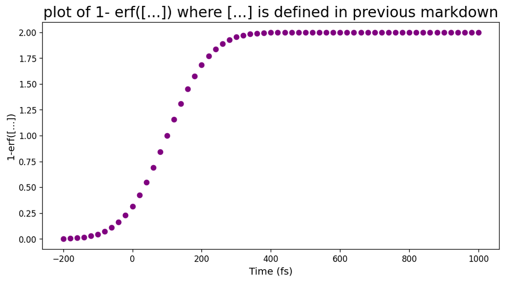

```python
o = 100
tt = 100

erf_arr = 1 - scipy.special.erf((o**2 - t*tt)/(np.sqrt(2)*o*tt))

print(erf_arr)
#print(new_time)


plt.figure(figsize=(10, 5), dpi=120)
plt.subplot(111)
'''
for i in range(len(t)):
        plt.plot(t[i], np.log(I_measured[i]), color="purple", marker = 'o',linestyle = 'none')
'''
#plt.plot(new_t, I, color="purple", marker = 'o',linestyle = 'none')
plt.plot(t, erf_arr, color="purple", marker = 'o',linestyle = 'none')
#plt.plot(new_t, curve, color="r", marker = 'none',linestyle = '-')
plt.title('plot of 1- erf([...]) where [...] is defined in previous markdown', fontsize = 18)
plt.xlabel('Time (fs)', fontsize = 12)
plt.ylabel('1-erf([...])', fontsize = 12)
```

#### (e) Based on your graph from part (d), simplify the model for $I(t)$ in the situation that $t$ is large relative to $\sigma$ and $\tau$. Then take the simplified model, linearize it, and perform a linear regression to extract an estimate for $\tau$. Remember to perform this linear regression only over the subset of the available data for which it is appropriate. Finally, plot your simplified model fit overlaid on the measured dataset $I(t)$ versus $t$.

```python
new_ttt = t[7:18]
print(new_ttt)
erf_arr = 1 - scipy.special.erf((o**2 - new_ttt*tt)/(np.sqrt(2)*o*tt))
print(erf_arr)
arrr = linear_regression(new_ttt,erf_arr)
print(arrr)

def functionn(timee):
    return [arrr[0]*x + arrr[1]]

for i in range(0,len())
# t =
```

[output not shown]

#### (f) Next perform a nonlinear regression, using the $\tau$ parameter determined in part (e), to extract values for $A$ and $\sigma$.

```python
arrr = linear_regression(np.log(new_ttt),np.log(erf_arr))
print(arrr)
#s 2/sqrt(pi)*integral(exp(-t**2), t=0..z
```

[output not shown]